# Financial modelling-sharp-ratio&datamining methods

### zeshi_yang——practice

```python
%pylab inline
import datetime
import numpy as np
import matplotlib.pyplot as plt
import matplotlib.dates as mdates
import pandas as pd
import pandas_datareader.data as web
import pprint
import statsmodels.tsa.stattools as ts
import statsmodels.api as sm
```

```python
#!pip install tushare
```

```python
import tushare as tu
```

```python
tu.set_token('4f49ca1a4c69691b78293d16b16ea69c552ea2f1bad188dc8f97bb1c')
pro = tu.pro_api()
```

```python
df = tu.pro_api().daily(ts_code='000001.SZ', start_date='20180701', end_date='20190318')
```

```python
df1= pro.daily(ts_code='000004.SZ', start_date='20180701', end_date='20180718')
```

# Function used in this notebook

```python
def get_close_price(symbolcode,st,en):
    df = pro.daily(ts_code=symbolcode, start_date=st, end_date=en)
    df=df[['ts_code','trade_date','close']]
    a=df['ts_code'][1]+'_close'
    df.columns = ['ts_code','日期',a]
    df=df.drop(['ts_code'], axis=1)
    df.sort_values(by=['日期'],inplace=True)
    return df
def get_multi_close_price(code_list,st,en):
    df=get_close_price(code_list[0],st,en)
    for i in range(1,len(code_list)):
        dfi=get_close_price(code_list[i],st,en)
        df = pd.merge(df,dfi, on='日期')
    return df
```

```python
df11=get_close_price('000006.SZ','20180701','20180718')
df11.head()
```

|  | 日期 | 000006.SZ_close |
| --- | --- | --- |
| 12 | 20180702 | 5.50 |
| 11 | 20180703 | 5.65 |
| 10 | 20180704 | 5.70 |
| 9 | 20180705 | 5.36 |
| 8 | 20180706 | 5.32 |

```python
clist=['000004.SZ','000005.SZ','000006.SZ']
```

```python
dff = get_multi_close_price(clist,'20180701','20180718')
dff.head()
```

|  | 日期 | 000004.SZ_close | 000005.SZ_close | 000006.SZ_close |
| --- | --- | --- | --- | --- |
| 0 | 20180702 | 19.10 | 2.90 | 5.50 |
| 1 | 20180703 | 19.35 | 2.93 | 5.65 |
| 2 | 20180704 | 19.21 | 2.93 | 5.70 |
| 3 | 20180705 | 19.08 | 2.86 | 5.36 |
| 4 | 20180706 | 19.04 | 2.87 | 5.32 |

```python
data = pro.query('stock_basic', exchange='', list_status='L', fields='ts_code,symbol,name,area,industry,list_date')
```

```python
listtt=data['ts_code'].tolist()
l=listtt[1:10]
```

```python
dff = get_multi_close_price(l,'20180301','20190318')
```

```python
dff.head()
```

|  | 日期 | 000002.SZ_close | 000004.SZ_close | 000005.SZ_close | 000006.SZ_close | 000007.SZ_close | 000008.SZ_close | 000009.SZ_close | 000010.SZ_close | 000011.SZ_close |
| --- | --- | --- | --- | --- | --- | --- | --- | --- | --- | --- |
| 0 | 20180309 | 33.46 | 21.19 | 4.12 | 8.80 | 15.36 | 7.45 | 6.26 | 4.70 | 16.40 |
| 1 | 20180312 | 32.62 | 21.75 | 4.14 | 8.65 | 14.90 | 7.50 | 6.33 | 4.72 | 16.45 |
| 2 | 20180313 | 32.48 | 23.40 | 4.10 | 8.70 | 14.73 | 7.40 | 6.42 | 4.88 | 16.35 |
| 3 | 20180314 | 32.70 | 22.34 | 4.11 | 8.29 | 13.90 | 7.38 | 6.33 | 4.73 | 16.04 |
| 4 | 20180315 | 32.66 | 22.70 | 3.99 | 7.95 | 13.62 | 7.27 | 6.26 | 4.79 | 16.23 |

# 1. 均值回复

关键的定量交易概念之一是均值回归。这个过程是指一个时间 显示出回归历史平均值的趋势。当价格很低时， 在期望系列将返回到一个平均值，从而我们进入市场获利。

随机游走（random walk）

随机游走是一个时间序列下一个定向运动完全独立于任何过去的运动。

$dx_t=dW_t$

$dW_t \sim N(0,dt)$

然而，平均回复时间序列不同。下一个时间段的时间序列值的变化正比于当前值。

$dx_t=\theta (\mu-x_t) dt+\sigma dW_t$

Augmented Dickey-Fuller (ADF) Test-检验单位根

$\Delta y_t=\alpha+\beta t+\gamma y_(t-1)+b_1\Delta y_(t-1)+...$

the null hypothesis $\gamma = 0$ against the alternative hypothesis of $\gamma < 0.$

```python
import statsmodels.tsa.stattools as ts
from datetime import datetime
import pandas_datareader.data as web
ts.adfuller(dff.iloc[:,1], 1)
```

```
(-2.506035011728324,
 0.11401283801477613,
 0,
 178,
 {'1%': -3.467631519151906,
  '5%': -2.8779183721695567,
  '10%': -2.575501353364474},
 408.26205068237886)
```

```python
不拒绝原假设，并不是均值回复。如正常概念一样，几乎金融数据满足非均值回复，例如几何布朗运动。

讨论此有什么用处呢？

配对交易
```

[output not shown]

# 2. 平稳性

$E(X_t)=constant$

$Var(X_t)=constant$

$cov(x_t,x_(t+s))=f(s) 与初始时间点无关$

Hurst Exponent- 时间序列的平稳性。

赫斯特指数计算背后的想法是我们可以使用对数价格的方差 系列来评估扩散行为的速度。

$Var(\gamma)=(log(t+\gamma)-log(t))^2$

$(log(t+\gamma)-log(t))^2 \sim \gamma^(2H)$

H <0.5 - 时间序列是平均回复

H = 0.5 - 时间序列是几何布朗运动

H> 0.5 - 时间序列具有趋势

```python
from numpy import cumsum, log, polyfit, sqrt, std, subtract
from numpy.random import randn
def hurst(ts):
    lags = range(2, 100)
    tau = [sqrt(std(subtract(ts[lag:], ts[:-lag]))) for lag in lags]
    # Use a linear fit to estimate the Hurst Exponent
    poly = polyfit(log(lags), log(tau), 1)
    # Return the Hurst exponent from the polyfit output
    return poly[0]*2.0
# Create a Gometric Brownian Motion, Mean-Reverting and Trending Series
gbm = log(cumsum(randn(100000))+1000)
mr = log(randn(100000)+1000)
tr = log(cumsum(randn(100000)+1)+1000)
# Output the Hurst Exponent for each of the above series
# and the price of Amazon (the Adjusted Close price) for
# the ADF test given above in the article
print("Hurst(GBM): %s" % hurst(gbm))
print("Hurst(MR): %s" % hurst(mr))
print("Hurst(TR): %s" % hurst(tr))
```

```
Hurst(GBM): 0.5048165657992686
Hurst(MR): 0.000179634529979838
Hurst(TR): 0.95671833259696
```

```python
print("Hurst(000001.sz): %s" % hurst(dff.iloc[:,1]))
```

```
Hurst(000001.sz): 0.4152229610160274
```

Cointegration 协整-配对交易

$ y(t)=\beta x(t) +\epsilon (t)$

其中$\epsilon (t)$是平稳均值回复

为了统计确认是否均值回复，我们可以使用增强型Dickey-Fuller测试或Hurst指数。

下面引入协整增强Dickey-Fuller（CADF）测试。 在线性组合下测试平稳性。

！注意，β会随时间变化 （dynamic hedge）

```python
#画价格序列，散点图，残差序列
def plot_price_series(df, ts1, ts2):
    months = mdates.MonthLocator()
    fig, ax = plt.subplots()
    ax.plot(df.index, df[ts1], label=ts1)
    ax.plot(df.index, df[ts2], label=ts2)
    ax.xaxis.set_major_locator(months)
    ax.xaxis.set_major_formatter(mdates.DateFormatter('%b %Y'))
    #ax.set_xlim(datetime.datetime(2012, 1, 1), datetime.datetime(2013, 1, 1))
    ax.grid(True)
    fig.autofmt_xdate()
    plt.xlabel('Month/Year')
    plt.ylabel('Price ($)')
    plt.title('%s and %s Daily Prices' % (ts1, ts2))
    plt.legend()
    plt.show()
def plot_scatter_series(df, ts1, ts2):
    plt.xlabel('%s Price ($)' % ts1)
    plt.ylabel('%s Price ($)' % ts2)
    plt.title('%s and %s Price Scatterplot' % (ts1, ts2))
    plt.scatter(df[ts1], df[ts2])
    plt.show()
def plot_residuals(df):
    months = mdates.MonthLocator() # every month
    fig, ax = plt.subplots()
    ax.plot(df.index, df["res"], label="Residuals")
    ax.xaxis.set_major_locator(months)
    ax.xaxis.set_major_formatter(mdates.DateFormatter('%b %Y'))
    #ax.set_xlim(datetime.datetime(2012, 1, 1), datetime.datetime(2013, 1, 1))
    ax.grid(True)
    fig.autofmt_xdate()
    plt.xlabel('Month/Year')
    plt.ylabel('Price ($)')
    plt.title('Residual Plot')
    plt.legend()
    plt.plot(df["res"])
    plt.show()
```

```python
dff.head()
```

|  | 日期 | 000002.SZ_close | 000004.SZ_close | 000005.SZ_close | 000006.SZ_close | 000007.SZ_close | 000008.SZ_close | 000009.SZ_close | 000010.SZ_close | 000011.SZ_close |
| --- | --- | --- | --- | --- | --- | --- | --- | --- | --- | --- |
| 0 | 20180309 | 33.46 | 21.19 | 4.12 | 8.80 | 15.36 | 7.45 | 6.26 | 4.70 | 16.40 |
| 1 | 20180312 | 32.62 | 21.75 | 4.14 | 8.65 | 14.90 | 7.50 | 6.33 | 4.72 | 16.45 |
| 2 | 20180313 | 32.48 | 23.40 | 4.10 | 8.70 | 14.73 | 7.40 | 6.42 | 4.88 | 16.35 |
| 3 | 20180314 | 32.70 | 22.34 | 4.11 | 8.29 | 13.90 | 7.38 | 6.33 | 4.73 | 16.04 |
| 4 | 20180315 | 32.66 | 22.70 | 3.99 | 7.95 | 13.62 | 7.27 | 6.26 | 4.79 | 16.23 |

```python
import datetime
```

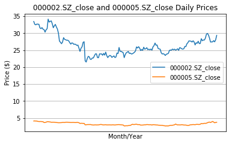

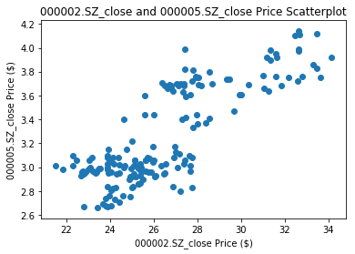

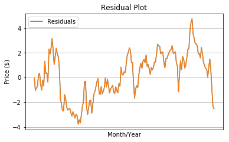

```
(-2.5549542649117556,
 0.10266920406241259,
 1,
 171,
 {'1%': -3.4691814633722453,
  '10%': -2.5758625549741803,
  '5%': -2.878595143532943},
 329.0963056354619)
```

```python
if __name__ == "__main__":
    start = datetime.datetime(2018, 1, 1)
    end = datetime.datetime(2019, 1, 1)
    plot_price_series(dff, "000002.SZ_close", "000005.SZ_close")
    plot_scatter_series(dff, "000002.SZ_close", "000005.SZ_close")
    y=dff["000002.SZ_close"]
    x=dff["000005.SZ_close"]
    res = sm.OLS(y,x).fit()
    #print(res.summary())
    beta_hr = res.params[0]
    #residual = y - b*x
    df["res"] = dff['000002.SZ_close'] - beta_hr*dff["000005.SZ_close"]
    plot_residuals(df)
    cadf = ts.adfuller(df["res"])
    pprint.pprint(cadf)
```

# 基本预测手法

为了评估分类器的性能，我们可以采用以下两种方法， 即命中率和混乱矩阵。

$hit rate=\frac{1}{n}\sum I(y_i=\hat y_i)$

混淆矩阵通过确定假阳性率来表征这个想法（已知的 统计上作为I型错误）和假阴性率（统计上称为II型错误） 用于监督分类器。 对于二元分类（向上或向下）的情况，我们将有一个2x2 矩阵：

\begin{pmatrix} U_T &U_F \\ D_F &D_T \end{pmatrix}

分类器

1. logistic regression

假设概率分布为

$P(Y=1|X=x)={\frac {e^{{x'\beta }}}{1+e^{{x'\beta }}}}$, 并且利用最大似然估计最大化联条件率分布解出参数。

(2) Discriminant analysis

在逻辑回归中，我们对给定前一个时间段的概率进行建模 两个滞后回报（P（Y = Uj|L1; L2））作为响应Y的条件分布使用逻辑函数。 在线性判别分析（LDA）中，对Li变量的分布进行建模 是分别基于给定的Y的观测值，并也假设Y的分布。而P（Y = Uj|L1; L2）是通过贝叶斯定理得到的。

$ P（Y = Uj|L1; L2) \propto P (L1; L2|Y = Uj) P(Y = Uj)$

(3). 支持向量机

为了训练支持向量机（SVM）， 它通过线性分离边界而分离不同的类，以达到最大化margin的目的，即使所有点尽量远离分类平面。 SVM的主要优势 是它们允许非线性扩大特征空间以包括显着的非线性， 同时仍然保持显着的计算效率，使用称为“内核”的过程。

决策树和随机树

决策树是-----监督分类技术 随机森林---多个决策树学习者（通常数以万计或更多）并结合预测，以减小预测误差。

```python
import sklearn
from sklearn.ensemble import RandomForestClassifier
from sklearn.linear_model import LogisticRegression
from sklearn.discriminant_analysis import LinearDiscriminantAnalysis as LDA
from sklearn.metrics import confusion_matrix
from sklearn.discriminant_analysis import QuadraticDiscriminantAnalysis as QDA
from sklearn.svm import LinearSVC, SVC
```

```python
ts= pro.daily(ts_code='000004.SZ', start_date='20180701', end_date='20181218').drop(['ts_code'], axis=1).sort_values(by='trade_date')
pc=ts["pct_chg"].tolist()
```

```python
tslag = pd.DataFrame(index=ts['trade_date'])
tslag["Today"] = ts["pct_chg"].tolist()
tslag["Volume"] = ts["vol"].tolist()
tslag.head()
```

| trade_date | Today | Volume |
| --- | --- | --- |
| 20180702 | -2.55 | 2210.20 |
| 20180703 | 1.31 | 3024.61 |
| 20180704 | -0.72 | 1940.01 |
| 20180705 | -0.68 | 1916.00 |
| 20180706 | -0.21 | 3543.99 |

```python
def create_lagged_series(symbol, st, en, lags=5):
    ts = tu.pro_api().daily(ts_code=symbol, start_date=st, end_date=en).drop(['ts_code'], axis=1).sort_values(by='trade_date')
     # Create the new lagged DataFrame
    tslag = pd.DataFrame(index=ts['trade_date'])
    tslag["Today"] = ts["pct_chg"].tolist()
    tslag["Volume"] = ts["vol"].tolist()
    # Create the shifted lag series of prior trading period close values
    for i in range(0, lags):
        tslag["Lag%s" % str(i+1)] = ts["pct_chg"].shift(1+i).tolist()
        tsret = pd.DataFrame(index=tslag.index)
        tsret["Volume"] = tslag["Volume"]
        tsret["Today"] = tslag["Today"]
    for i,x in enumerate(tsret["Today"]):
        if (abs(x) < 0.0001):
             tsret["Today"][i] = 0.0001
            # Create the lagged percentage returns columns
    for i in range(0, lags):
        tsret["Lag%s" % str(i+1)] = \
        tslag["Lag%s" % str(i+1)]
        # Create the "Direction" column (+1 or -1) indicating an up/down day
    tsret["Direction"] = np.sign(tsret["Today"])
    tsret = tsret[tsret.index >= st]
    tsret=tsret.dropna(axis=0,how='any')
    return tsret
```

```python
snpret = create_lagged_series(
    "000002.SZ", '20180110',
    '20190227', lags=5
    )
snpret.head()
```

| trade_date | Volume | Today | Lag1 | Lag2 | Lag3 | Lag4 | Lag5 | Direction |
| --- | --- | --- | --- | --- | --- | --- | --- | --- |
| 20180117 | 812191.93 | -1.07 | 8.39 | 4.33 | 1.14 | -1.46 | -0.47 | -1.0 |
| 20180118 | 558848.40 | -0.03 | -1.07 | 8.39 | 4.33 | 1.14 | -1.46 | -1.0 |
| 20180119 | 548758.23 | -0.86 | -0.03 | -1.07 | 8.39 | 4.33 | 1.14 | -1.0 |
| 20180122 | 406526.41 | 0.28 | -0.86 | -0.03 | -1.07 | 8.39 | 4.33 | 1.0 |
| 20180123 | 648657.50 | 3.67 | 0.28 | -0.86 | -0.03 | -1.07 | 8.39 | 1.0 |

```python
if __name__ == "__main__":
    # Create a lagged series of the S&P500 US stock market index
    snpret = create_lagged_series(
    "000005.SZ", '20180110',
    '20190227', lags=5
    )
    # Use the prior two days of returns as predictor
    # values, with direction as the response
    X = snpret[["Lag1","Lag2"]]
    y = snpret["Direction"]
    # The test data is split into two parts: Before and after 1st Jan 2005.
    start_test = '20181010'
    # Create training and test sets
    X_train = X[X.index < start_test]
    X_test = X[X.index >= start_test]
    y_train = y[y.index < start_test]
    y_test = y[y.index >= start_test]
    #it is fixed parameters
    # Create the (parametrised) models
    print("Hit Rates/Confusion Matrices:\n")
    models = [("LR", LogisticRegression()),
    ("LDA", LDA()),
    ("QDA", QDA()),
    ("LSVC", LinearSVC()),
    ("RSVM", SVC(
    C=1000000.0, cache_size=200, class_weight=None,
    coef0=0.0, degree=3, gamma=0.0001, kernel='rbf',
    max_iter=-1, probability=False, random_state=None,
    shrinking=True, tol=0.001, verbose=False)
    ),
    ("RF", RandomForestClassifier(
    n_estimators=1000, criterion='gini',
    max_depth=None, min_samples_split=2,
    min_samples_leaf=1, max_features='auto',
    bootstrap=True, oob_score=False, n_jobs=1,
    random_state=None, verbose=0)
    )]
    # Iterate through the models
    for m in models:
        # Train each of the models on the training set
        m[1].fit(X_train, y_train)
        # Make an array of predictions on the test set
        pred = m[1].predict(X_test)
        # Output the hit-rate and the confusion matrix for each model
        print("%s:\n%0.3f" % (m[0], m[1].score(X_test, y_test)))
        print("%s\n" % confusion_matrix(pred, y_test))
```

```
Hit Rates/Confusion Matrices:

LR:
0.511
[[18 23]
 [23 30]]

LDA:
0.511
[[18 23]
 [23 30]]

QDA:
0.553
[[16 17]
 [25 36]]

LSVC:
0.521
[[18 22]
 [23 31]]

RSVM:
0.564
[[ 4  4]
 [37 49]]
```

```
RF:
0.479
[[12 20]
 [29 33]]
```

sklearn.linear_model.LogisticRegression(penalty=’l2’, dual=False, tol=0.0001, C=1.0, fit_intercept=True, intercept_scaling=1, class_weight=None, random_state=None, solver=’liblinear’, max_iter=100, multi_class=’ovr’, verbose=0, warm_start=False, n_jobs=1)

sklearn.discriminant_analysis.LinearDiscriminantAnalysis(solver=’svd’, shrinkage=None, priors=None, n_components=None, store_covariance=False, tol=0.0001)

Solver to use, possible values: ‘svd’: Singular value decomposition (default). Does not compute the covariance matrix, therefore this solver is recommended for data with a large number of features. ‘lsqr’: Least squares solution, can be combined with shrinkage. ‘eigen’: Eigenvalue decomposition, can be combined with shrinkage.

分类 SVC( C=1000000.0, cache_size=200, class_weight=None, coef0=0.0, degree=3, gamma=0.0001, kernel='rbf', max_iter=-1, probability=False, random_state=None, shrinking=True, tol=0.001, verbose=False) )

回归 clf = svm.SVR() SVR(C=1.0, cache_size=200, coef0=0.0, degree=3, epsilon=0.1, gamma='auto', kernel='rbf', max_iter=-1, shrinking=True, tol=0.001, verbose=False)

# 表现和风险评估

收益率分析：直接对收益率进行计算。不足：没有考虑波动率风险

Sharp Ratio: 比例越高，投资组合越佳。

$S_a = \frac{E[R_a-R_b]}{\sigma_a} = \frac{E[R_a-R_b]}{\sqrt{\mathrm{var}[R_a-R_b]}},$

```python
def annualised_sharpe(returns, N=252):
    return np.sqrt(N) * returns.mean() / returns.std()
def stock_sharpe_ratio(symbol,st,en):
    pdf = tu.pro_api().daily(ts_code=symbol, start_date=st, end_date=en).drop(['ts_code'], axis=1).sort_values(by='trade_date')
    # Use the percentage change method to easily calculate daily returns
    pdf['daily_ret'] = pdf['pct_chg']
    pdf['excess_daily_ret'] = pdf['daily_ret'] - 0.05/252
    # Return the annualised Sharpe ratio based on the excess daily returns
    return annualised_sharpe(pdf['excess_daily_ret'])
```

```python
stock_sharpe_ratio('000007.SZ','19961111','20190311')
```

```
0.2602441627611384
```

VaR(Value at Risk),在一定概率水平（置信度）下，组合在未来特定时期内的最大可能损失。

用公式表示为：

P(ΔPΔt≤VaR)=a

字母含义如下：

P——资产价值损失小于可能损失上限的概率。

ΔP——某一金融资产在一定持有期Δt的价值损失额。

VaR——给定置信水平a下的在险价值，即可能的损失上限。

a——给定的置信水平

$\mu + Z_\alpha \sigma$

```python
from scipy.stats import norm
def var_cov_var(P, c, mu, sigma):
    alpha = norm.ppf(1-c, mu, sigma)
    return P - P*(alpha + 1)
if __name__ == "__main__":
    st = '20180911'
    en = '20190911'
    symbol='000005.SZ'
    xxx=tu.pro_api().daily(ts_code=symbol, start_date=st, end_date=en).drop(['ts_code'], axis=1).sort_values(by='trade_date')
    xxx["rets"] = xxx["pct_chg"]
    P = 1e6 # 1,000,000 USD
    c = 0.99 # 99% confidence interval
    mu = np.mean(xxx["rets"])
    sigma = np.std(xxx["rets"])
    var = var_cov_var(P, c, mu, sigma)
    print("Value-at-Risk: $%0.2f" % var)
```

```
Value-at-Risk: $5693871.48
```

```python
!ipython nbconvert --to html 'Financial modelling-sharp-ratio&datamining methods.ipynb'
```

[output not shown]